# chargement des données

```r
summary(res)
```

```
##
## Call:
## CA(X = data_afc)
##
## The chi square of independence between the two variables is equal to 58.66001 (p-value =  1.1457e-05 ).
##
## Eigenvalues
##                        Dim.1   Dim.2   Dim.3   Dim.4
## Variance               0.005   0.002   0.001   0.000
## % of var.             60.357  25.112  13.795   0.737
## Cumulative % of var.  60.357  85.468  99.263 100.000
##
## Rows
##                    Iner*1000    Dim.1    ctr   cos2    Dim.2    ctr   cos2
## Associate        |     2.210 | -0.109 24.865  0.515 |  0.103 53.211  0.458 |
## Director         |     2.329 |  0.166 41.404  0.813 |  0.002  0.010  0.000 |
## Entry level      |     1.532 | -0.045 17.877  0.534 | -0.041 35.631  0.443 |
## Executive        |     0.033 | -0.004  0.005  0.007 | -0.021  0.332  0.189 |
## Internship       |     0.281 |  0.085  0.329  0.054 |  0.224  5.467  0.371 |
## Mid-Senior level |     1.194 |  0.041 15.520  0.595 |  0.016  5.349  0.085 |
##                   Dim.3    ctr   cos2
## Associate        -0.024  5.464  0.026 |
## Director         -0.080 41.323  0.185 |
## Entry level      -0.009  3.391  0.023 |
## Executive        -0.034  1.630  0.510 |
## Internship       -0.243 11.713  0.437 |
## Mid-Senior level  0.030 36.479  0.320 |
##
## Columns
##                    Iner*1000    Dim.1    ctr   cos2    Dim.2    ctr   cos2
## All              |     3.099 |  0.198 66.009  0.974 |  0.029  3.498  0.021 |
## Midwest          |     1.263 | -0.057 12.207  0.442 | -0.062 35.165  0.530 |
## Northeast        |     0.882 | -0.021  2.420  0.125 |  0.017  3.871  0.084 |
## South            |     1.666 | -0.055 12.151  0.334 |  0.068 45.103  0.515 |
## West             |     0.669 |  0.033  7.213  0.493 | -0.028 12.363  0.352 |
##                   Dim.3    ctr   cos2
## All               0.002  0.025  0.000 |
## Midwest           0.010  1.554  0.013 |
## Northeast        -0.051 66.705  0.791 |
## South             0.037 24.023  0.151 |
## West              0.016  7.693  0.120 |
```

```r
res$eig[,2]
```

```
##      dim 1      dim 2      dim 3      dim 4
## 60.3565902 25.1117152 13.7948645  0.7368301
```

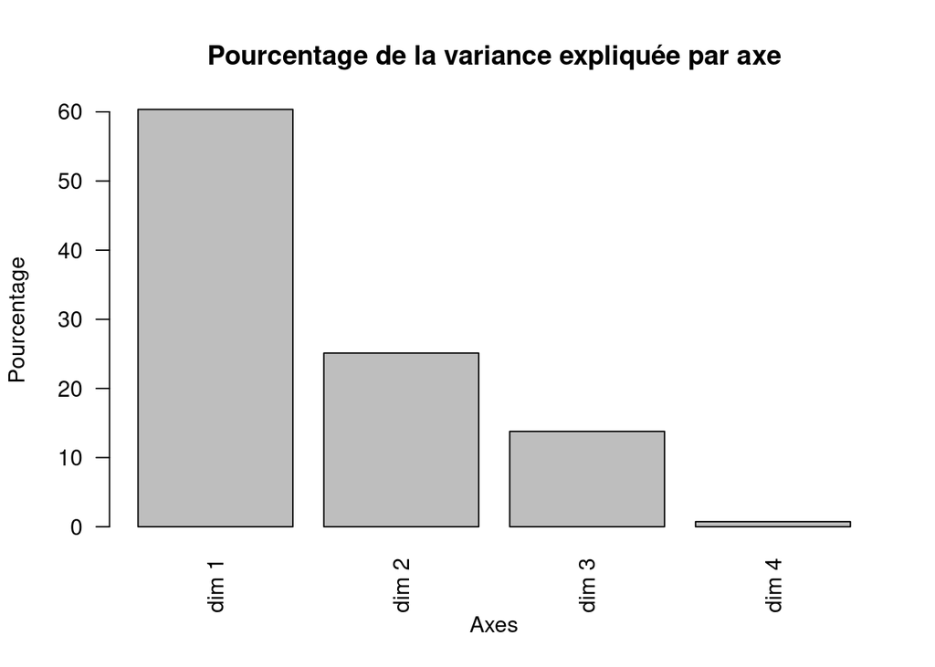

```r
# Barplot des valeurs propres pour déterminer le nombre d'axes à retenir
barplot(res$eig[, 2], main = "Pourcentage de la variance expliquée par axe",  xlab = "Axes", ylab = "Pourcentage", las = 2)
```

on va garder 2 axes car les axes Dim 1 et Dim 2 réprésente plus 80%

```r
# # Extraire les cos² pour les lignes et les colonnes
# row_cos2 <- res$row$cos2[, 1:2]  # Premiers deux axes pour les lignes
# col_cos2 <- res$col$cos2[, 1:2]  # Premiers deux axes pour les colonnes
#
# # Configuration de l'affichage graphique
# par(mfrow = c(1, 1), mar = c(5, 8, 4, 2))
#
# # Barplot horizontal pour les cos² des lignes sur les deux premiers axes
# barplot(row_cos2[, 1], main = "Cos² Niveau Expérience sur Axe 1", xlab = "Cos²", horiz = TRUE, las = 1)
# barplot(row_cos2[, 2], main = "Cos² Niveau Expérience sur Axe 2", xlab = "Cos²", horiz = TRUE, las = 1)
#
# # Barplot horizontal pour les cos² des colonnes sur les deux premiers axes
# barplot(col_cos2[, 1], main = "Cos² des Region sur Axe 1", xlab = "Cos²", horiz = TRUE, las = 1)
# barplot(col_cos2[, 2], main = "Cos² des Region sur Axe 2", xlab = "Cos²", horiz = TRUE, las = 1)
#
# par(mfrow = c(1, 1))  # Réinitialise la disposition normale
```

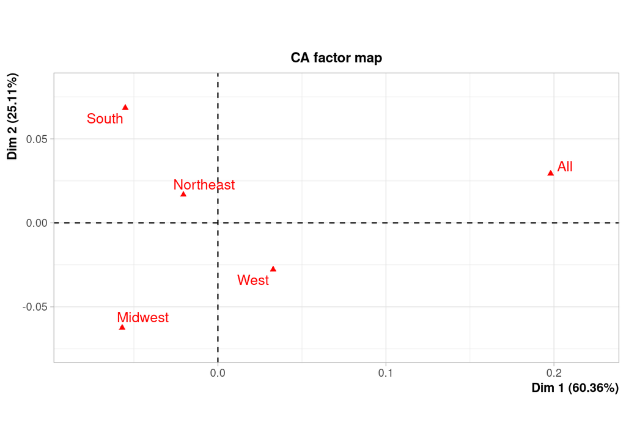

```r
plot(res, invisible="row")
```

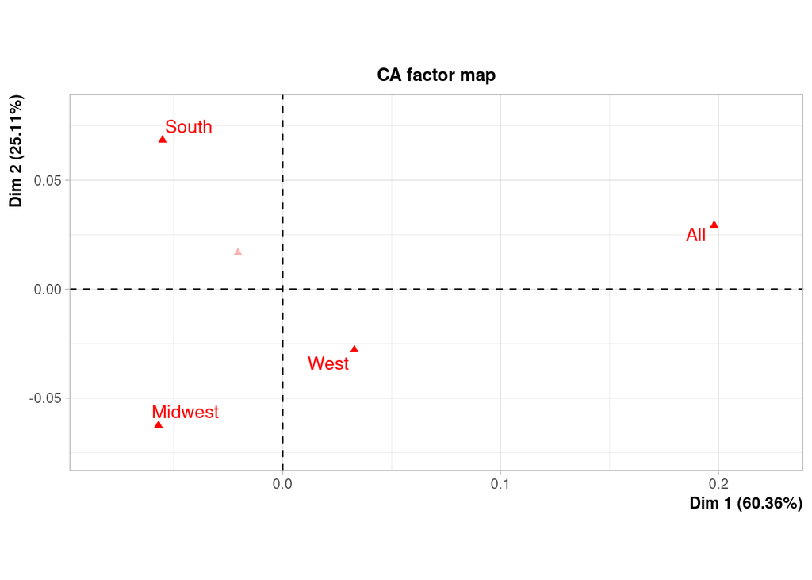

```r
plot(res, invisible="row", selectCol="cos2 0.8")
```

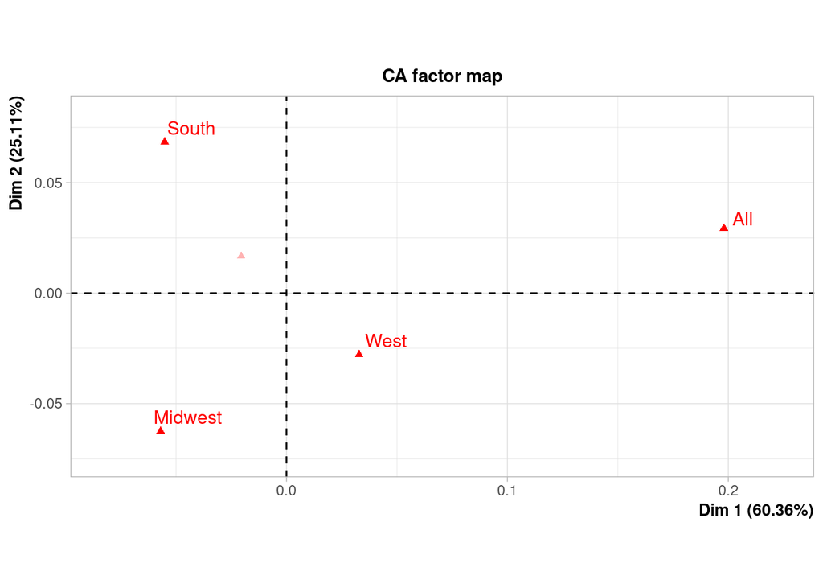

```r
plot(res, invisible="row", selectCol="contrib 4")
```

```r
res$col$contrib
```

```
##               Dim 1     Dim 2       Dim 3      Dim 4
## All       66.009353  3.498283  0.02506317 22.7660471
## Midwest   12.206535 35.165005  1.55385513 33.8759997
## Northeast  2.419665  3.870724 66.70455006  0.6967532
## South     12.150951 45.103329 24.02304285  0.4257397
## West       7.213496 12.362659  7.69348880 42.2354603
```

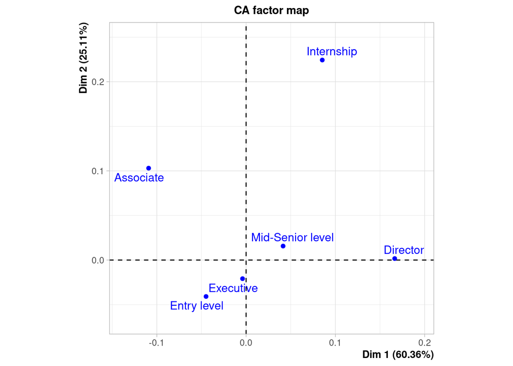

```r
plot(res, invisible="col")
```

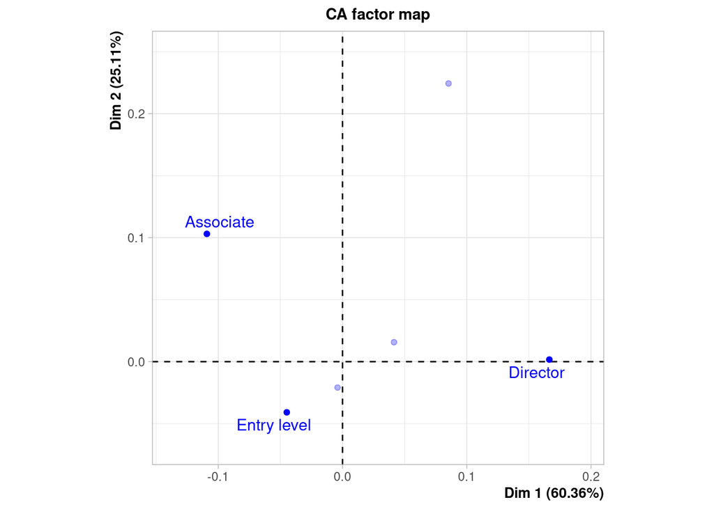

```r
plot(res, invisible="col", selectRow ="cos2 0.7")
```

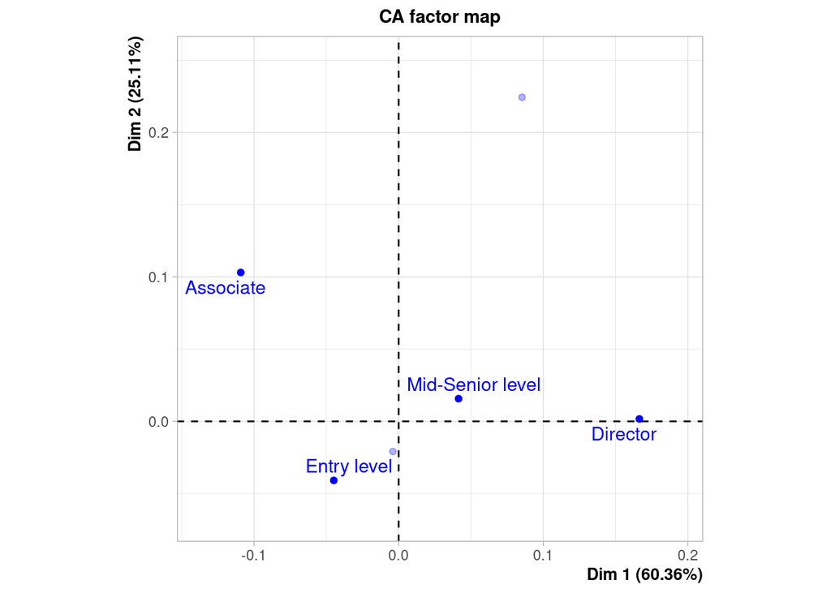

```r
plot(res, invisible="col", selectRow ="contrib 4")
```

```r
res$row$contrib
```

```
##                         Dim 1        Dim 2     Dim 3      Dim 4
## Associate        24.864881232 53.211203972  5.463957  5.0251720
## Director         41.404163833  0.009976316 41.322673  5.1749554
## Entry level      17.876774200 35.630951696  3.390672  1.5965259
## Executive         0.005053711  0.331741606  1.630171 17.5689087
## Internship        0.328964161  5.467118025 11.713377 69.7456358
## Mid-Senior level 15.520162863  5.349008385 36.479150  0.8888021
```

- Axes 1 : Les niveaux “Director” et “Associate” ont les contributions les plus élevées sur cet axe. “Director” est positionné à tout à droite tandis que “Associate” tout à gauche. On peux donc supposer que l’axe 1 capte probablement les différences en termes de responsabilité ou de complexité des postes. Les postes de direction impliquent des responsabilités plus élevées, tandis que les postes d’associé sont généralement de niveau inférieur.
- Axes 2 : “Associate” a une contribution significative sur l’Axe 2 et est positionné légèrement au-dessus de l’axe horizontal. Tandis que “Entry level” apparaît également avec une contribution notable sur cet axe, mais est positionné un peu plus en bas. Ces 2 types de niveaux peuvent partager une similarité dans la compréhension générale du travail, car ils sont tous deux souvent associés à des rôles d’initiation où les employés apprennent les bases de leurs fonctions et de l’organisation. Mais elles peuvent différer en termes d’autonomie, niveau de responsabilité ou de la porté des tâches. Car les employés en début de carrière peuvent avoir un niveau d’autonomie plus faible et nécessiter une supervision dans leurs tâches, tandis que les associés peuvent être plus autonomes. Donc l’axe 2 pourrait être interprété comme reflétant les variations dans l’autonomie et la responsabilité au sein des postes de départ de carrière,

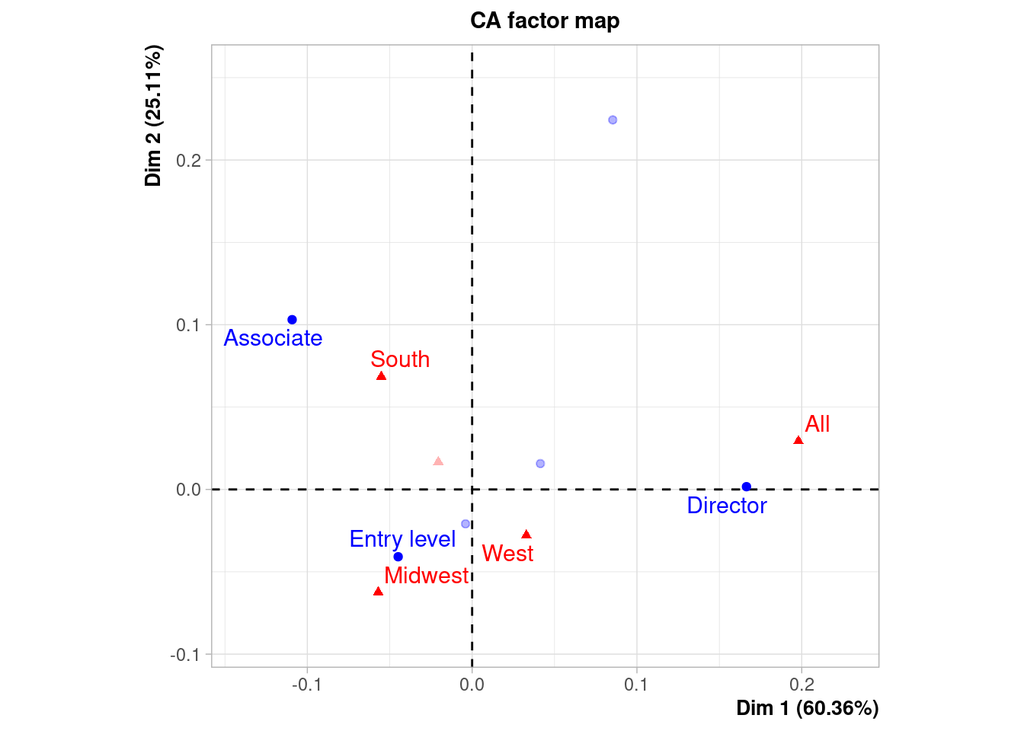

```r
plot(res, selectRow ="cos2 0.8", selectCol ="cos2 0.7")
```

- On observe que “Entry level” est très proche avec la région “Midwest” ce qui suggère que cette zone a une demande plus importante pour des postes de niveau débutant, ce qui est semble assez cohérent. En effet, ce dernier se concentre plus dans les industries traditionnelles. Ces secteurs offrent souvent de nombreuses opportunités d’emploi ne nécessitant pas une expérience préalable.
- On remarque aussi que Associate”, est très proche de “South”. Cela suggère que la région “South” pourrait avoir une demande significative pour des postes d’associé, ce qui est due à ses activités plus orientés dans les secteurs innovants tels que l’énergie et l’aérospatiale. Dans ces domaines, les postes d’associé exigent généralement un peu plus d’expérience et de compétences que les postes de niveau “Entry level”, car ils sont souvent impliqués dans des activités de recherche et développement plus avancées.
- Enfin on voir que les postes de “Director” sont proches de “All” sur le graphique, indiquant une demande dispersée à travers tout le pays pour ces positions à haute responsabilité. Ce qui signifie que les compétences de leadership et de gestion sont valorisées de manière uniforme à travers différentes régions, reflétant la nécessité pour les entreprises, quelle que soit leur localisation, de recruter des cadres supérieurs capables de diriger des équipes et de piloter des stratégies d’affaires efficacement.

# 2 AFC experience - district

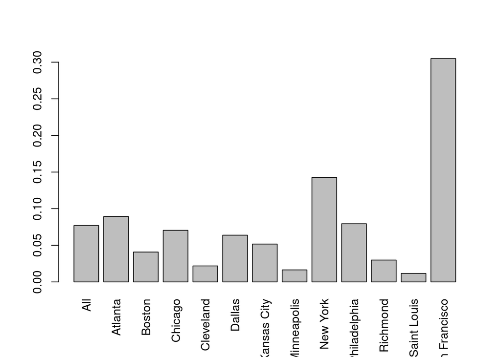

```r
# Calcul de la table de contingence
data_afc <- xtabs(~ formatted_experience_level + district, data = data)
# print(data_afc)

# Barplot montrant la proportion d'offres d'emploi dans chaque district par rapport au total des offres
barplot(apply(data_afc,2,sum)/sum(data_afc),las=3) # selon le district
```

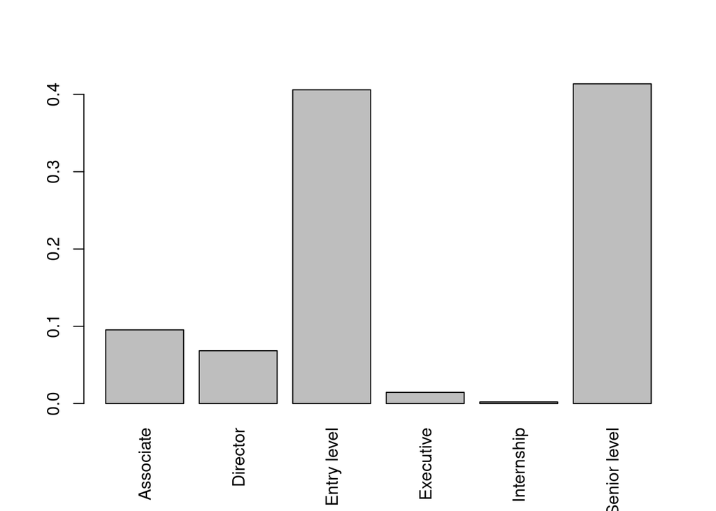

```r
barplot(apply(data_afc,1,sum)/sum(data_afc),las=3) # selon l'experience
```

```r
# test d'indépendance
chi_test <- chisq.test(data_afc)
print(chi_test)
```

```
##
##  Pearson's Chi-squared test
##
## data:  data_afc
## X-squared = 129.05, df = 60, p-value = 5.791e-07
```

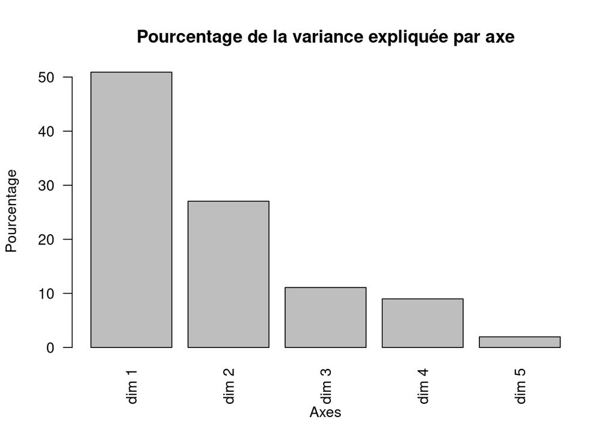

```r
res=CA(data_afc, graph = FALSE)

# Barplot des valeurs propres pour déterminer le nombre d'axes à retenir
barplot(res$eig[, 2], main = "Pourcentage de la variance expliquée par axe", xlab = "Axes", ylab = "Pourcentage", las = 2)
```

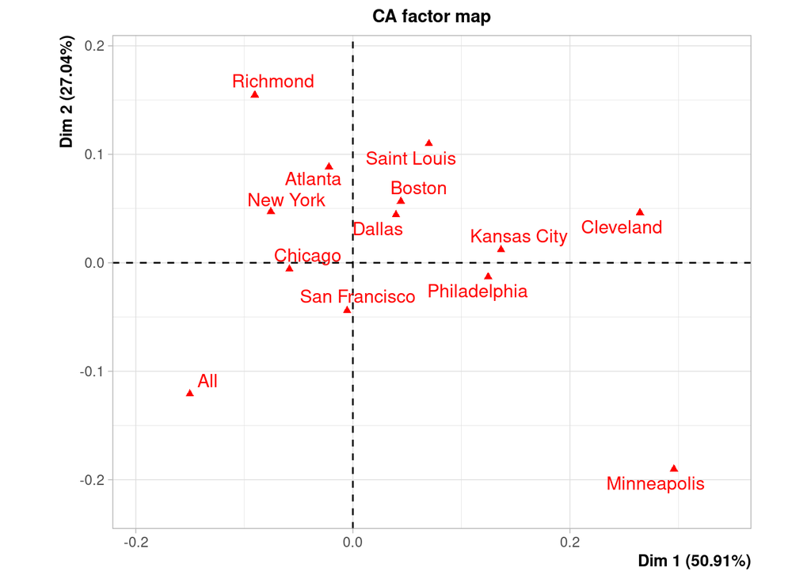

```r
plot(res, invisible="row")
```

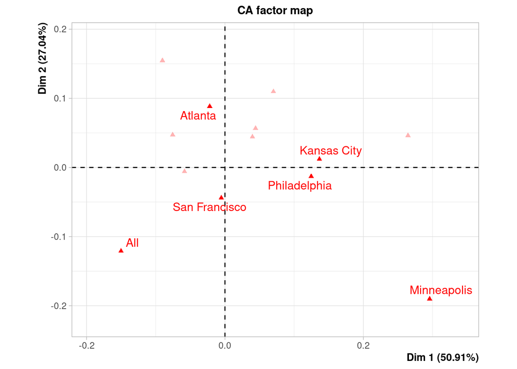

```r
plot(res, invisible="row", selectCol="cos2 0.8")
```

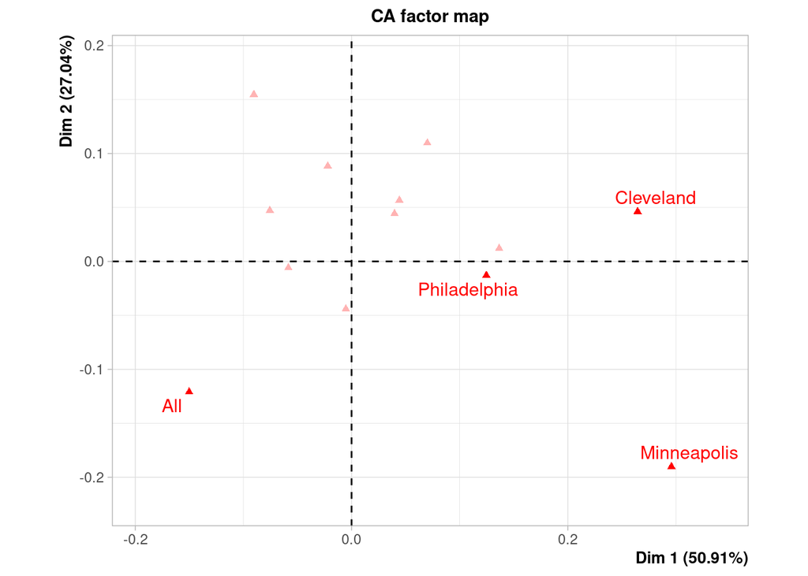

```r
plot(res, invisible="row", selectCol="contrib 4")
```

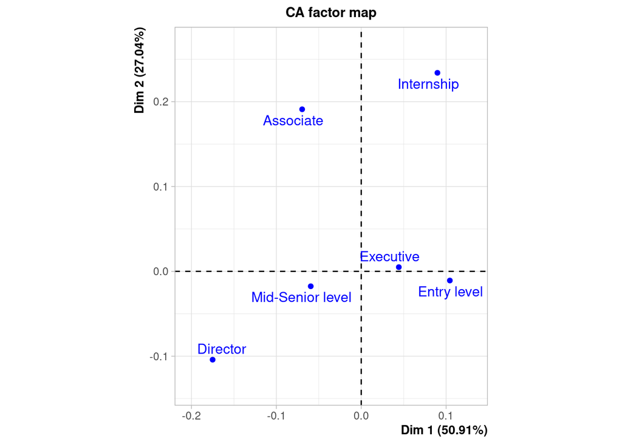

```r
plot(res, invisible="col")
```

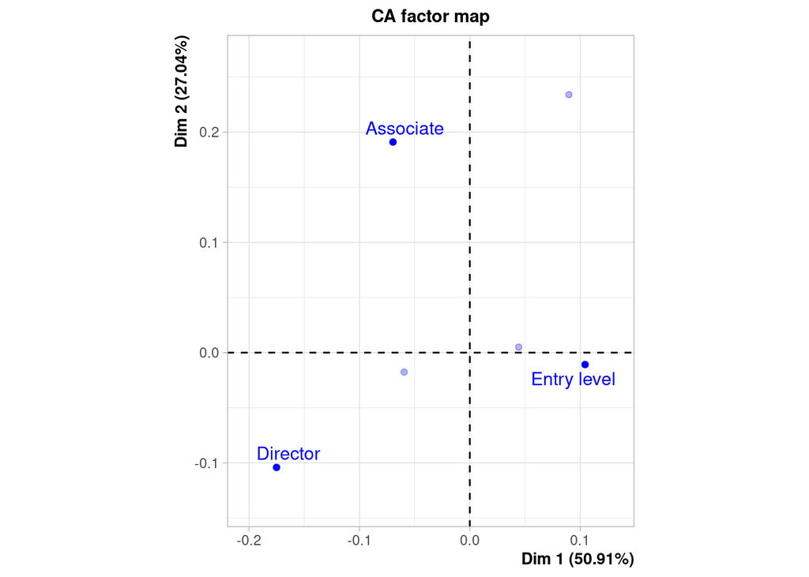

```r
plot(res, invisible="col", selectRow ="cos2 0.7")
```

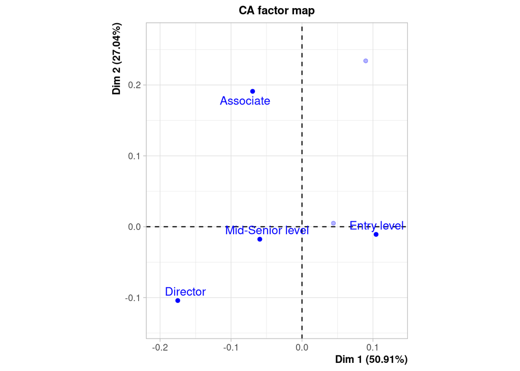

```r
plot(res, invisible="col", selectRow ="contrib 4")
```

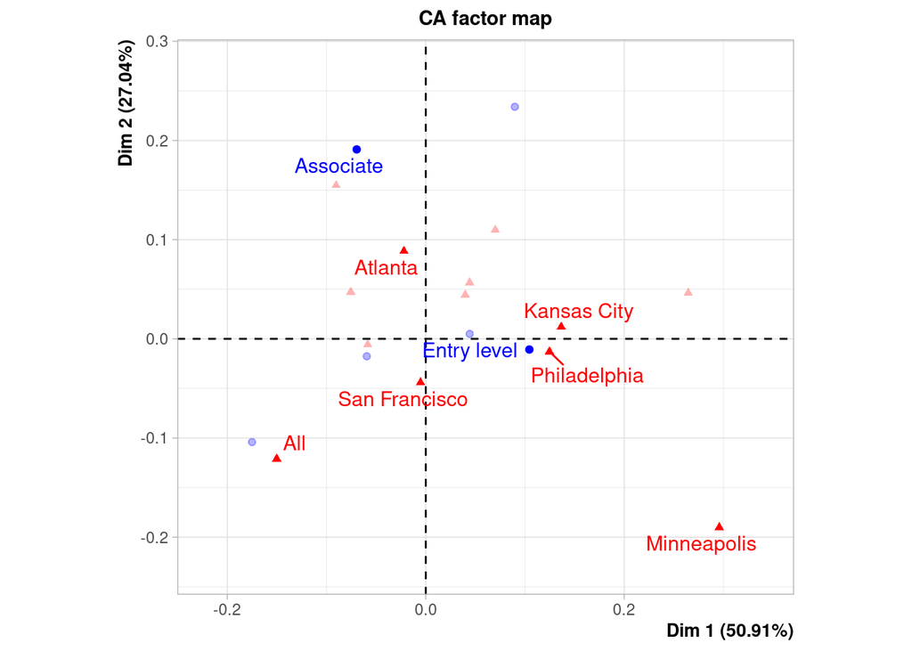

```r
plot(res, selectRow ="cos2 0.8", selectCol ="cos2 0.8")
```